# lab4

```python
%matplotlib inline
import numpy as np
import matplotlib
import matplotlib.pyplot as plt
import scipy
from scipy import stats
import h5py
import xarray as xr

#this sets the size of the plot to something useful
plt.rcParams["figure.figsize"] = (20,15)
hf = h5py.File('gammaray_lab4.h5', 'r')
data = np.array(hf.get('data'))
data[:,0]
hf.close()
```

Problem 1: 1) I tried to directly plot the diagrams using solar phase, earth longitude, and the data counts with time for the first four hundred thousand data points. As results, there is some visible pattern shown in the time-counts relationship with constant fluctuation, while no obvious conclusion can be made from the other two graphs.

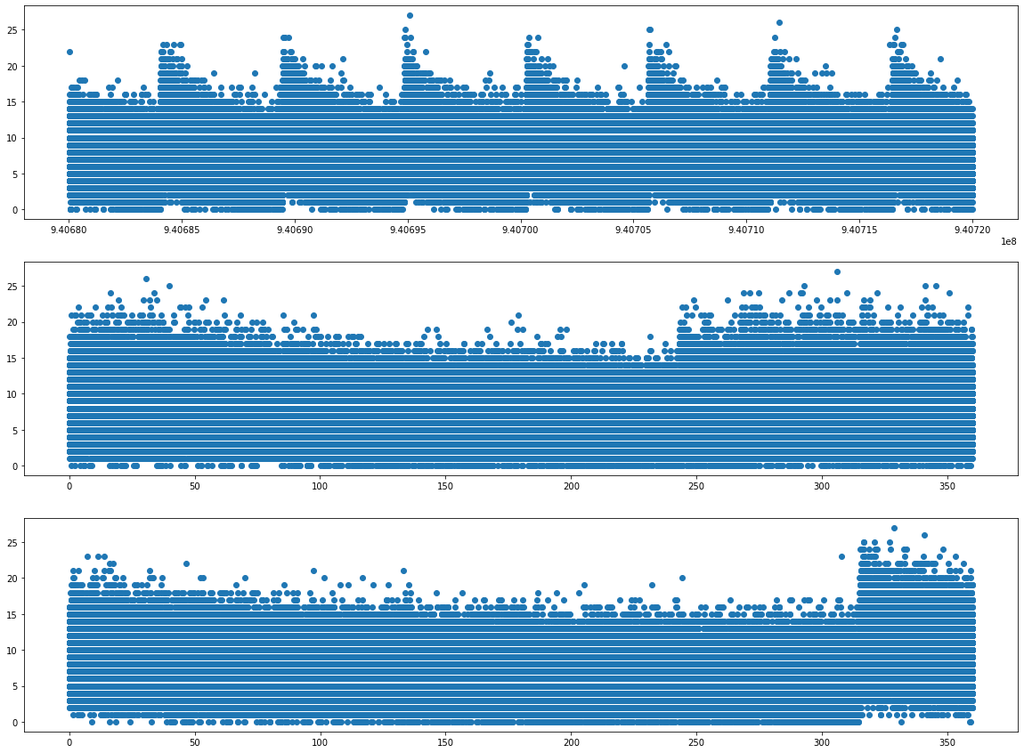

```python
time = data[0]
solar_phase = data[1]
earth_longitude = data[2]
counts = data[3]
x = 400000

fig, (ax1,ax2,ax3) = plt.subplots(3, 1)
ax1.plot(time[0:x], counts[0:x], 'o', lw=2)
ax2.plot(solar_phase[0:x], counts[0:x], 'o', lw=2)
ax3.plot(earth_longitude[0:x], counts[0:x], 'o', lw=2)
```

Since the points are concentrated in certain areas, we can use 2d histogram to look at them. To answer question 2), we can see there is a huge gap in the graph earth longitude versus counts between 300 and 350 degrees. The background just entirely broken and goes to a high mean from a low mean of counts, which might due to some glitch.

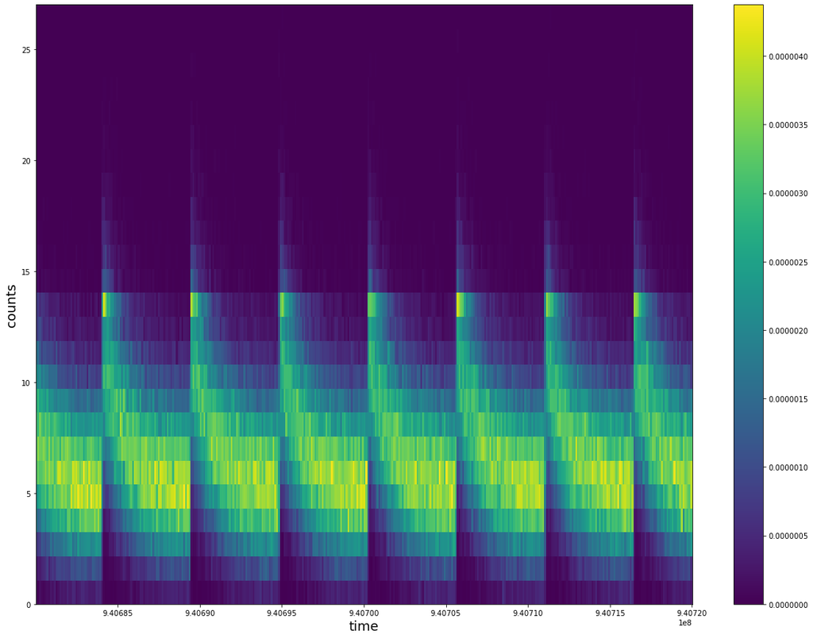

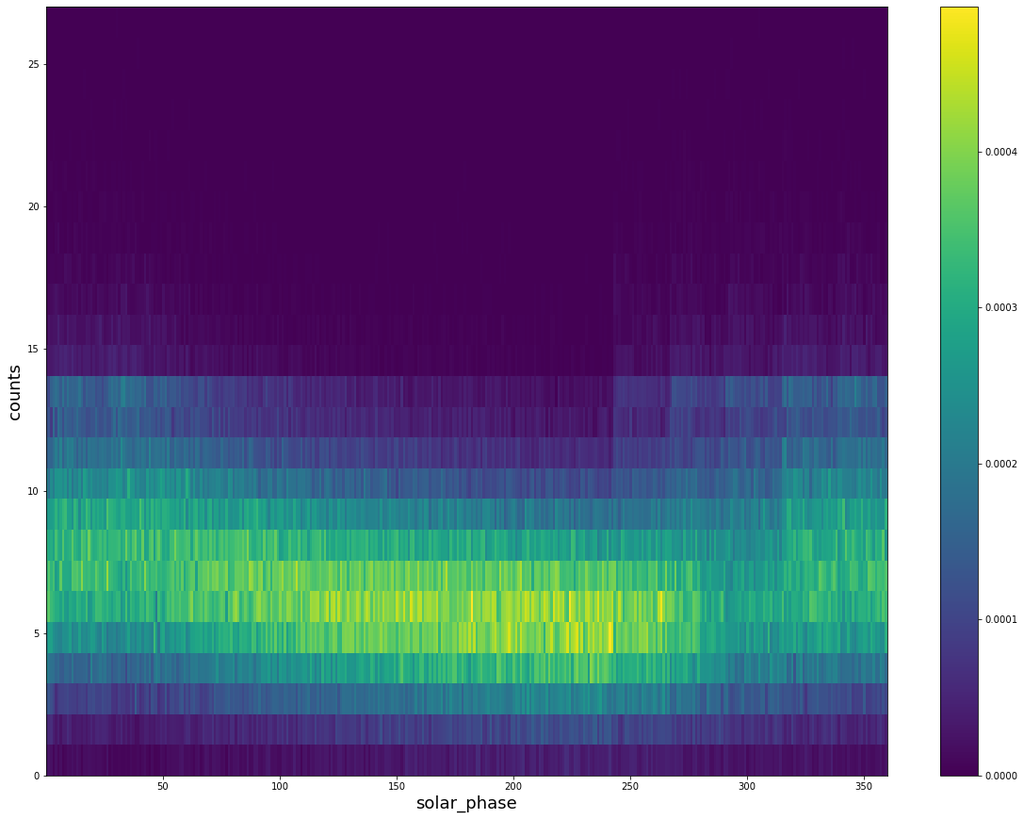

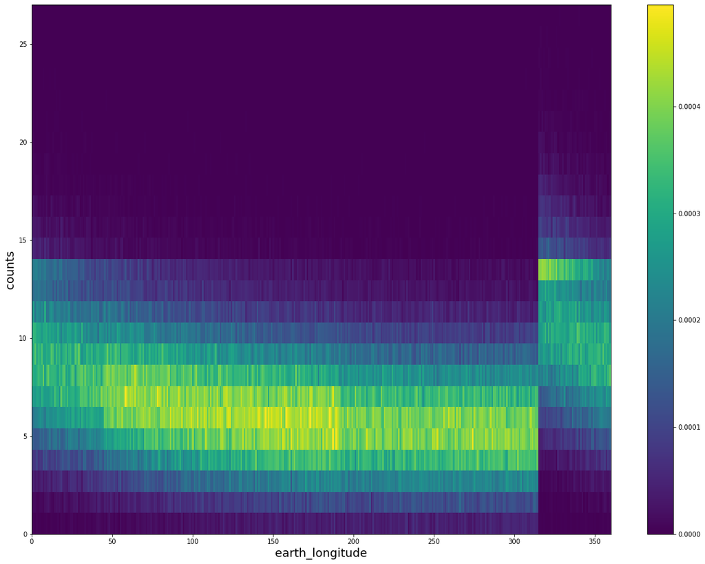

```python
b = (360,25)
plt.hist2d(time[0:x], counts[0:x], bins=b, density=True)
plt.ylabel("counts", fontsize = 18)
plt.xlabel("time", fontsize = 18)
plt.colorbar()
plt.show()

plt.hist2d(solar_phase[0:x], counts[0:x], bins=b, density=True)
plt.ylabel("counts", fontsize = 18)
plt.xlabel("solar_phase", fontsize = 18)
plt.colorbar()
plt.show()

plt.hist2d(earth_longitude[0:x], counts[0:x], bins=b, density=True)
plt.ylabel("counts", fontsize = 18)
plt.xlabel("earth_longitude", fontsize = 18)
plt.colorbar()
plt.show()
```

We can also take a look at time versus the other two variables. They are relatively simple oscillation functions that are almost in phase.

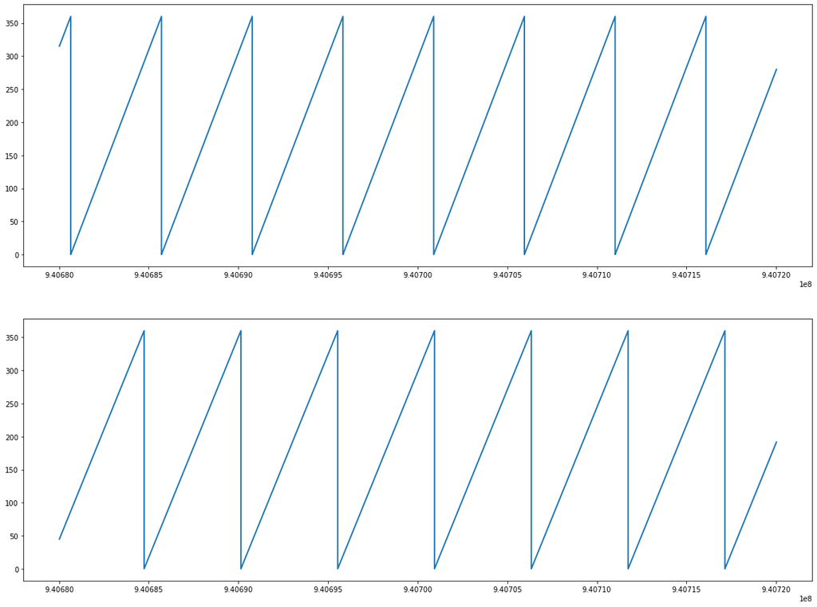

```python
fig, (ax1,ax2) = plt.subplots(2, 1)
ax1.plot(time[0:x], solar_phase[0:x], lw=2)
ax2.plot(time[0:x], earth_longitude[0:x], lw=2)
```

3) So I might want to build a model with Poisson distribution in each loop of data, since the density is the highest at around counts of five and spread out to both sides. As we see the mean value in the Poisson model approaching 5 as in the data, however, it barely reflects the abundance of other detection with higher mean particle counts. But just based on the amount of data of particles counts, we can say the particles counts may follow a Poisson distribution. And then, the average particle count approaches to the mean as time evolves, saying that the time dependence must follow another model that has a increasing distribution, which can be combined with the model of particle counts to reach a similar background distribution.

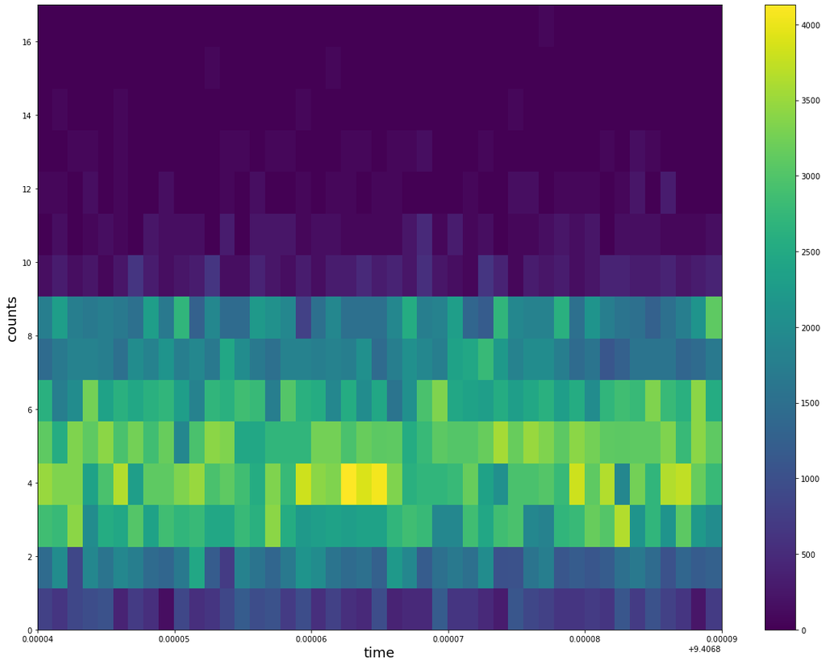

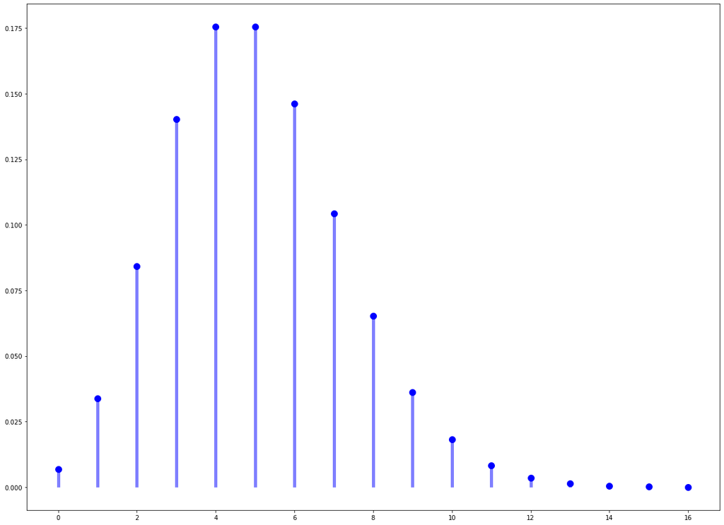

```python
mu = 5
s = 10000
time_model = np.linspace(9.40684, 9.40689, s)

counts_model = stats.poisson.rvs(mu, loc = 0, size = s)
b = (45,15)

plt.hist2d(time_model, counts_model, bins=b, density=True)
plt.ylabel("counts", fontsize = 18)
plt.xlabel("time", fontsize = 18)
plt.colorbar()
plt.show()

pts = np.arange(stats.poisson.ppf(0.00001, 5), stats.poisson.ppf(.99999, 5))
plt.plot(pts, stats.poisson.pmf(pts, 5), 'bo', ms=10, label='poisson pmf')
plt.vlines(pts, 0, stats.poisson.pmf(pts, 5), colors='b', lw=5, alpha=0.5)
plt.show()
```

4) The calculated 5-sigma is 18, and based on the graph, the discover threshold falls beyond the bright point at about 14 particle counts in each period of oscillation.

```python
stats.poisson.ppf(1-3.5e-6, 5)
```

```
18.0
```

Problem 2 a) b) The contamination is not obvious in the image stack as we can see in the image stack. From the data, it doesn't show any relation with respect to time, and it is spatially consistent since the points of brightness are evenly distributed.

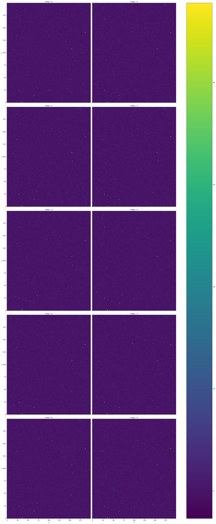

```python
f = h5py.File('images.h5', 'r')
stack = xr.DataArray(f.get('imagestack')[:,:,:], coords=[np.arange(200), np.arange(200), np.arange(10)], dims=['x', 'y', 'image']).transpose('image','y','x')
stack.plot(center=False, col='image', col_wrap=2, size=10)
images_data = np.array(f.get('imagestack'))
plt.show()
```

In order to find out the pdf() of data, we can just plot the probability distribution of the brightness of all pixels. And we can get a Gaussian Distribution as the background distribution.

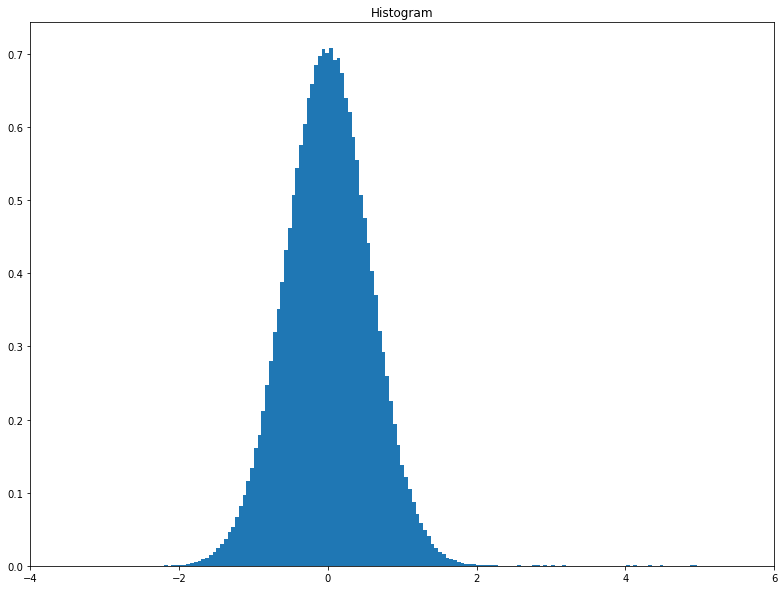

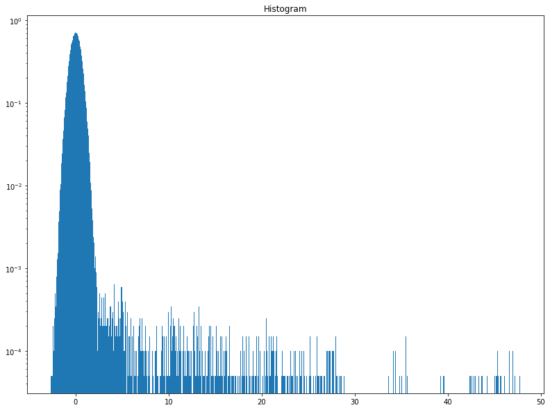

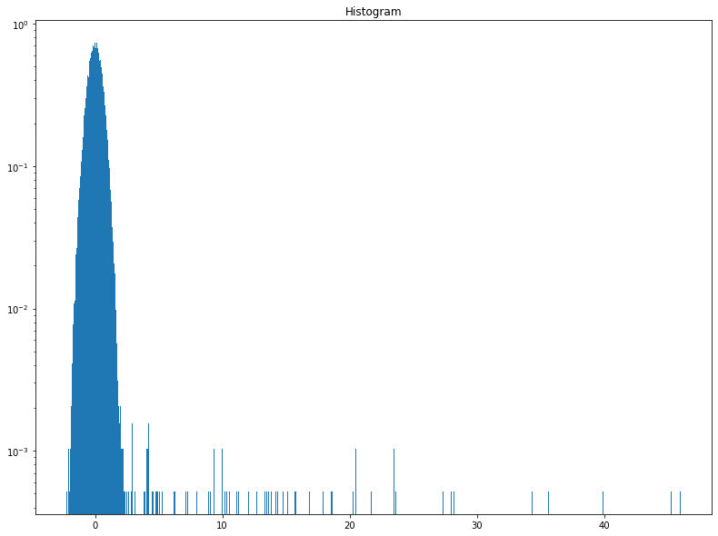

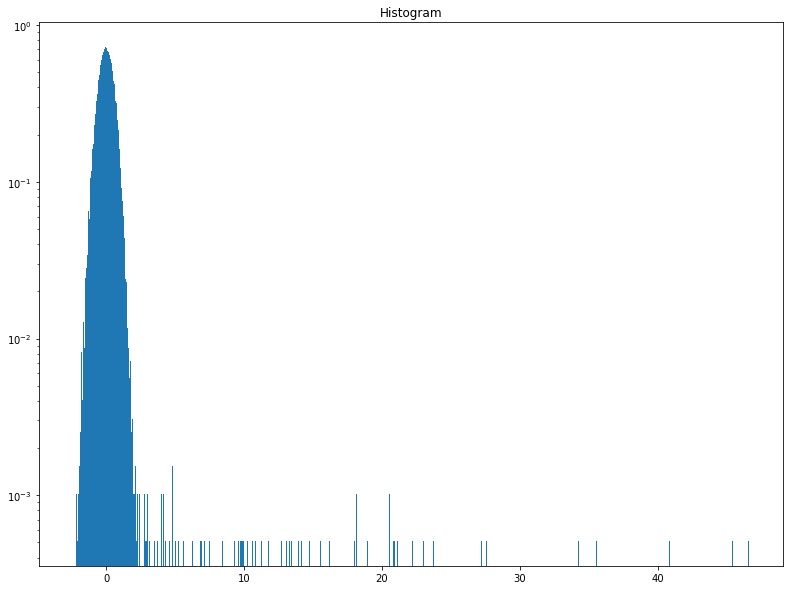

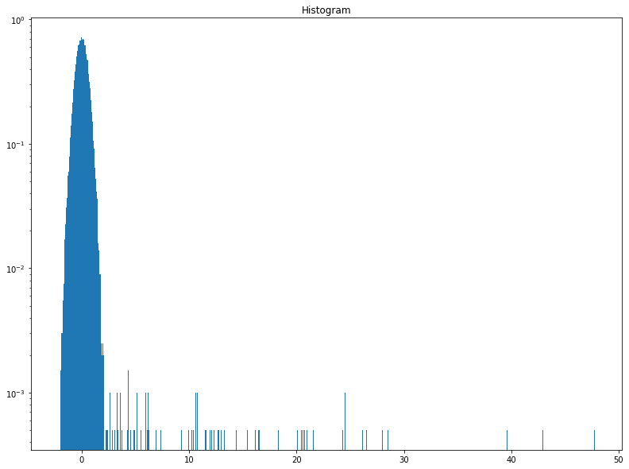

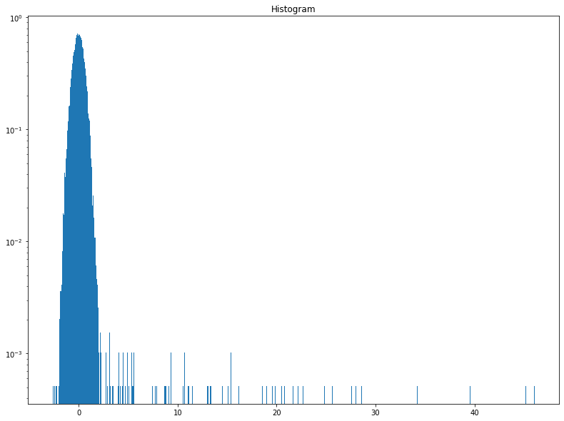

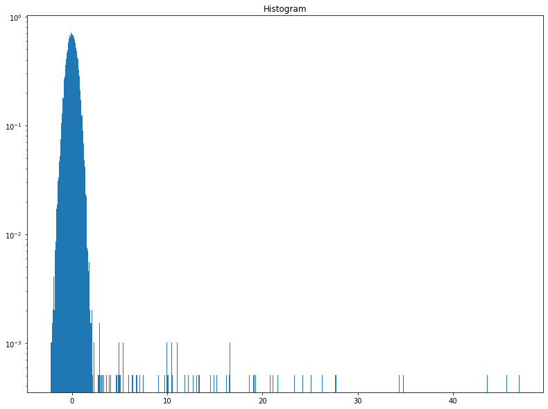

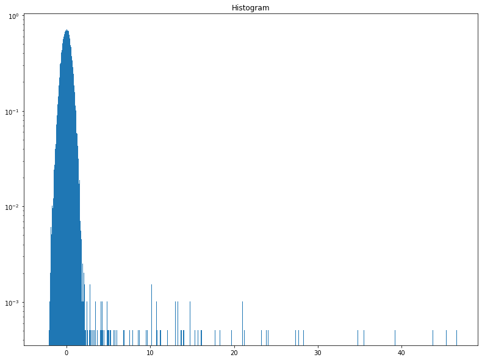

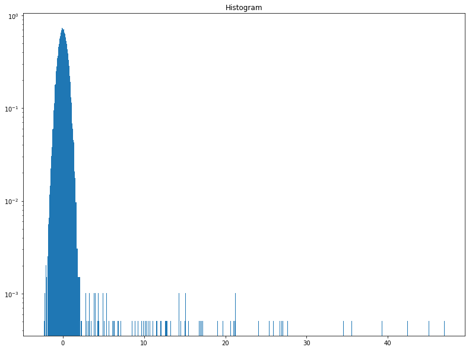

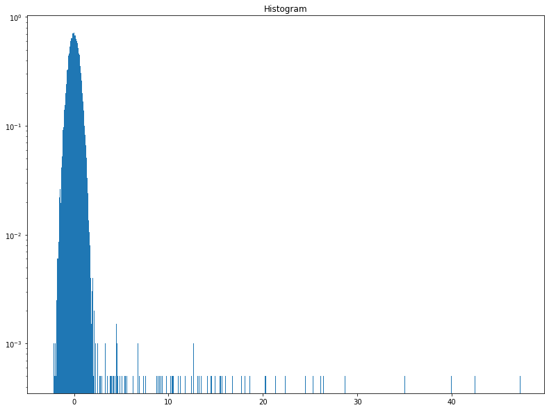

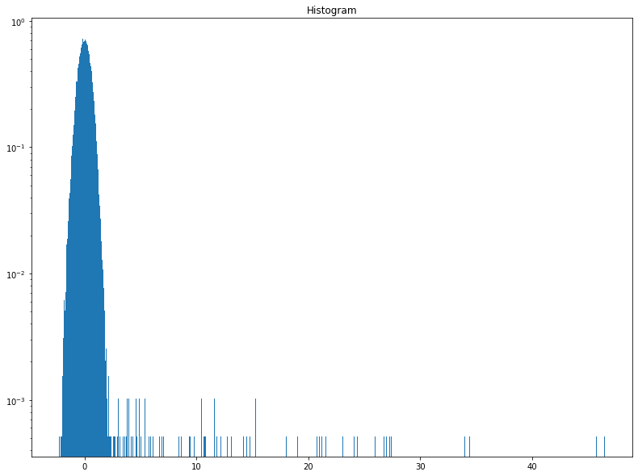

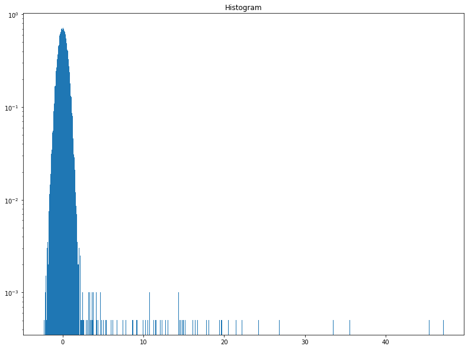

```python
stack.plot.hist(bins=1000, density=True, size=10)
plt.xlim([-4, 6])
plt.show()
stack.plot.hist(bins=1000, density=True, log=True, size=10)
plt.show()

for i in range(10):
    stack[i].plot.hist(bins=1000, density=True, log=True, size=10)
    plt.show()
```

3) Since I'm only looking for the faintest stars, I can use a preassumed Gaussian distribution as the background to find all the signals, and then I pick the lowest value as the faintest stars above the threshold of 5-sigma. Then I compare all the images with each other and obtain a average from it, in order to find out the noise beside the signals and the background and clean out the noise from each image. Finally we get a background distribution with sigma of 0.6, and the 5-sigma is 3.0. So every image has its faintest stars just at the places with signal density of 3.

```python
noise = np.zeros((200, 200))
for i in range(10):
    for j in range(i+1, 10):
        noise += stack[i] - stack[j]
noise = noise/45
```

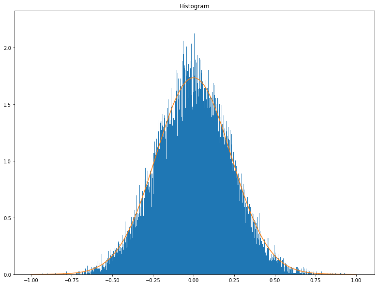

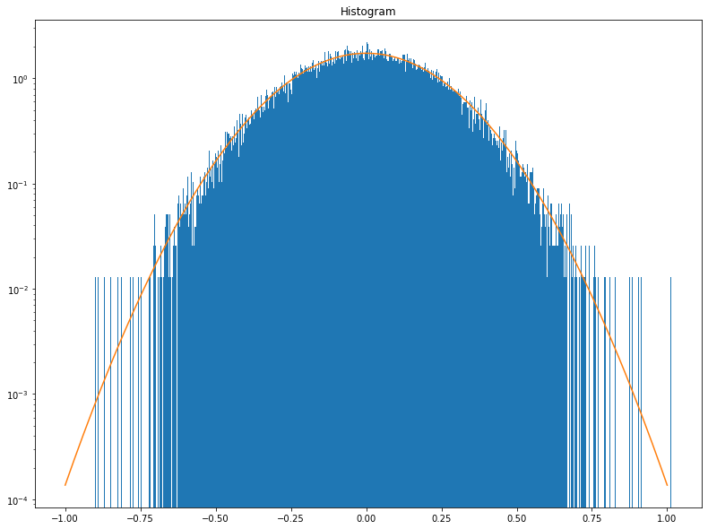

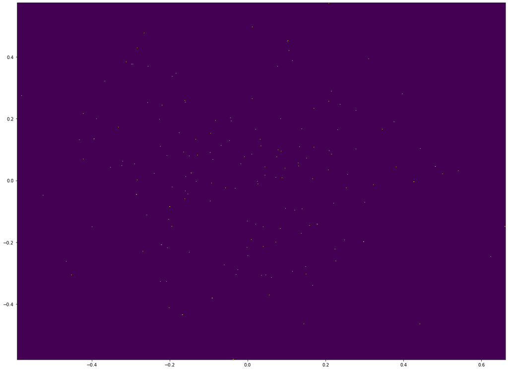

```python
noise.plot.hist(bins=1000, density=True, log=False, size=10)
x = np.linspace(-1, 1, 200)
sigma = 0.23
plt.plot(x, stats.norm.pdf(x, scale = sigma))
plt.show()

noise.plot.hist(bins=1000, density=True, log=True, size=10)
plt.plot(x, stats.norm.pdf(x, scale = sigma))
plt.show()

plt.hist2d(noise[0], noise[1], bins=1000, density=True)
plt.show()
```

```python
for i in range(10):
    stack[i] = stack[i] - bkgd
```

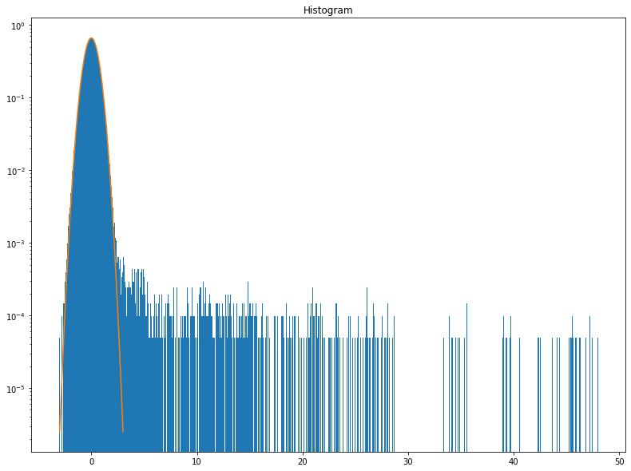

```python
x = np.linspace(-3, 3, 200)
sigma = 0.6
stack.plot.hist(bins=1000, density=True, log=True, size=10)
plt.plot(x, stats.norm.pdf(x, scale = sigma))
plt.show()
```

4) Because I'm comparing all of the images together, while my partner only wants to find one spot in an image, the background pdf might not be the same.